# MoBPS (1.15.20)

Torsten Pook

2026-08-24

This file descripts all updates of the software since 1.14.00

## Memory

Primary updates in the latest MoBPS version are the speed of simulations and on memory efficiency of the population-list object, which should result simulations being 60% faster and requiring between 15 - 50% less memory. These changes are primary in the backend of MoBPS with no active changes in coding required by the frontend user (except installing). Details on this are descriped below.

## Tracking of performance

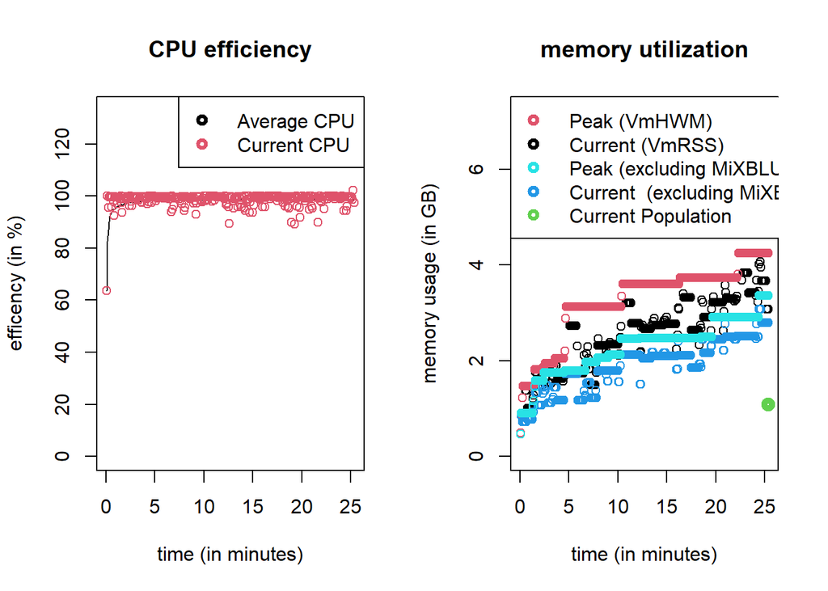

```r
library(MoBPS)
population = creating.diploid(nsnp = 1000, nindi = 100, tracking = TRUE,
                              tracking.interval = 1)
# tracking interval is in seconds
# its recommend to stay with default of 10 seconds or longer unless simulations are very small

for(index in 1:10){
  population = breeding.diploid(population, breeding.size = 100)
}

# load in a larger simulation with something useful to plot
load("C:/Users/pook001/OneDrive - Wageningen University & Research/population_sibs10_16.RData")
get.performance.plot(population)
```

## miraculix & RandomFieldsUtils (v1.6.0.4)

New package versions support R4.6

New version is necessary for Memory improvements mentioned above

Added Transform() function to extract a subset of SNPs/Individuals from a compressed genotype object which avoids decompression now fully (further memory reduction)

Install RandomFieldsUtils first, then miraculix.

## Kinship calculation

Added function get.kinship.snp() to approximate underlying true kinship. The output is very close to underlying true empirical kinship but computes substantially faster.

```r
library(MoBPS)

set.seed(1)

population = creating.diploid(nsnp = 1000, nindi = 100, chr.nr = 5,
                              chromosome.length = 1)
# tracking interval is in seconds
# its recommend to stay with default of 10 seconds or longer unless simulations are very small

for(index in 1:10){
  population = breeding.diploid(population, breeding.size = 100)
}

population = breeding.diploid(population, breeding.size = 100)


t1 = Sys.time()
kinship_ped = get.kinship.exp(population, gen = 12)
t2 = Sys.time()
kinship_real = get.kinship.emp(population, gen = 12)
t3 = Sys.time()
kinship_snp = get.kinship.snp(population, gen = 12)
t4 = Sys.time()

print(t2-t1) # 0.09707594 secs
print(t3-t2) # 32.17936 secs
print(t4-t3) # 0.3661618 secs

print(cor(as.numeric(kinship_ped), as.numeric(kinship_real))) # 0.9811004
print(cor(as.numeric(kinship_ped), as.numeric(kinship_snp))) # 0.9809516
print(cor(as.numeric(kinship_snp), as.numeric(kinship_real))) # 0.9999002
```

## Documentation & material

Workshop material was updated to account for all changes in parameter names since 1.13.

## OCS (relationship.matrix.ocs)

relationship.matrix.ocs now allows users to provide their own relationship matrix, or constructed it based on underlying true kinship (relationship.matrix.ogc = “emp_kinship”) or the computationally much more efficient approximated underlying true kinship (relationship.matrix.ogc = “emp_fast_kinship”).

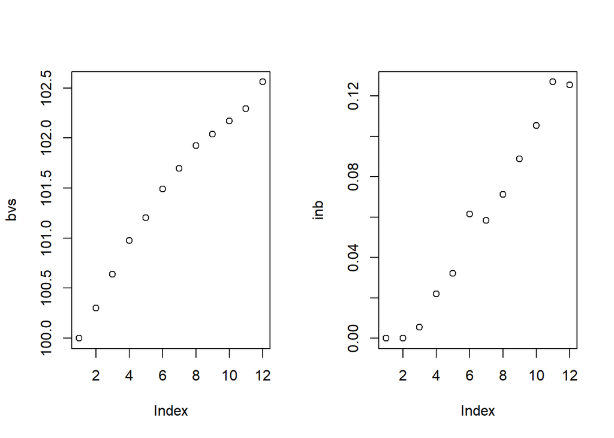

```r
set.seed(1)
population = creating.diploid(nsnp = 100, nindi = 100, n.additive = c(100,100,100), mean.target = 100, var.target = 1)

population = breeding.diploid(population, heritability = 0.3)

for(index in 1:10){
  population = breeding.diploid(population, phenotyping.gen = index)
  population = breeding.diploid(population,
                                breeding.size = 100,
                                selection.size = c(20,20),
                                selection.criteria = "pheno"
                                )
}

population = breeding.diploid(population, phenotyping.gen = 11)

A = get.kinship.exp(population, gen = get.ngen(population))

# last generation are automatically used as selection candidates
population = breeding.diploid(population, breeding.size = 100,
                              selection.criteria = "pheno",
                        relationship.matrix.ocs = A,
                              ocs = TRUE,
                              ocs.target = "max.BV",
                              ocs.ub.sKin.increase = 0.02)

bvs = inb = numeric(12)
for(index in 1:12){
  bvs[index] = mean(get.bv(population, gen = index))
  inb[index] = mean(inbreeding.emp(population, gen = index))
}
par(mfrow = c(1,2))
plot(bvs)
plot(inb)
```

## Backend improvements

### MiXBLUP (mostly backend)

Activating mixblup.ta / mixblup.tac will now automatically activate hpblup

Internal storage of included SNPs in the last MiXBLUP evaluation that is used for MSV calculation and DGV-PBLUP

Prints/Logs now display information on number of iterations and convergence statistics for MiXBLUP evaluations

### Run-time / performance improvements (mostly backend)

Line-by-line profiling of the main steps of simulations and improvement of all identified bottlenecks

- Simulation of meiosis is now ~60% faster
- Calculation of underlying true genomic values is now ~40% faster
- Writting of MiXBLUP input files is now ~90% faster

### Memory improvements (mostly backend)

Storage needs for individual specific data was improved to require between 15% - 50% less memory depending on the structure of the breeding program

Within that:

- Storage needs for recombination points was improved by storing them with lower precision (still 0.000001M precise) to require ~50% less memory to this
- Storage need of individuals generated through copy.individual and combine was substantially improved to require ~80% less memory. To return to old storage precision set recombination.precision = 1 in creating.diploid()
- Various separately stored individual information is now jointly stored or if not necessary not stored

### C++ -code (mostly backend)

MoBPS now includes C++ code to improve efficiency is selected steps (previously this was all miraculix)

- Generation of genotype files when using MiXBLUP
- Approximation of underlying true kinship (get.kinship.snp)
- Avoid convergence of SNP matrices to Logial matrices and back
- More efficient computation of recombination points and which are inherited

For Window-user this means, that you have to install Rtools https://cran.r-project.org/bin/windows/Rtools/ or you can no longer install through .tar.gz. Installing through the .zip version of the package still works.